# 1. Newton's First Law

# 4. Reference Frame

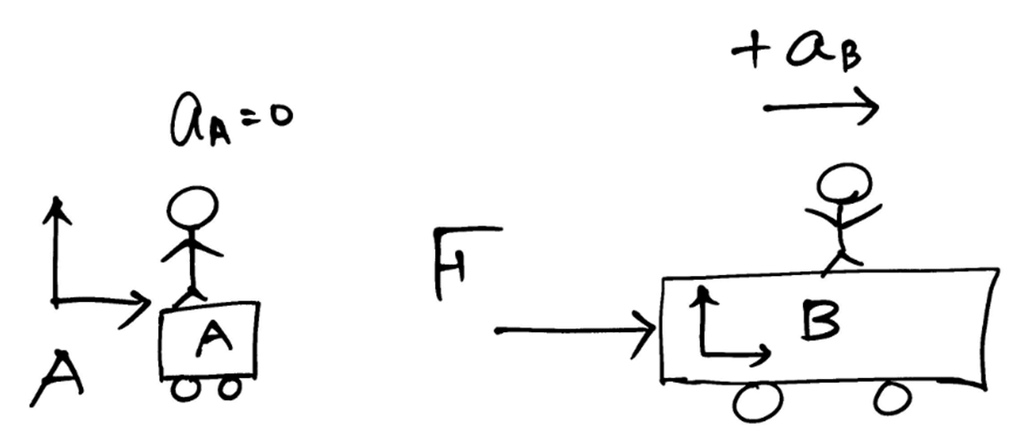

**Inertial Reference Frame**

- $A$'s point of view ($A$ reference)

$$\begin{array}{l} A \text{: at rest}\\ B \text{: moves with } +a \end{array} \quad \text{Apply the } 2^{nd} \text{ Law}$$

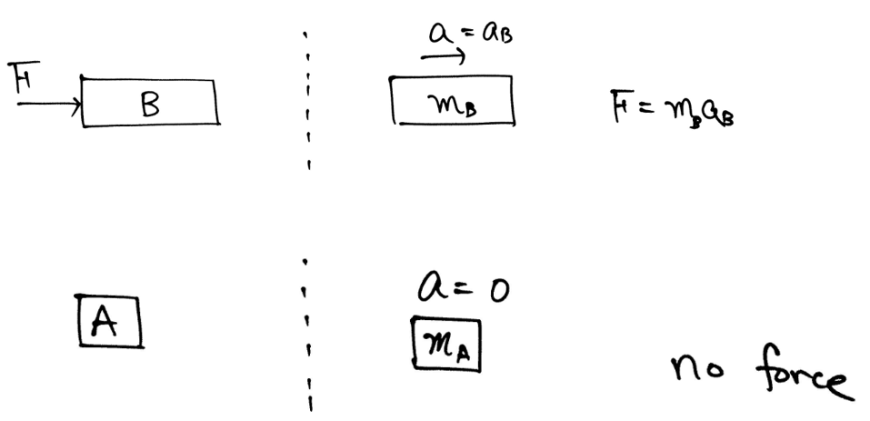

**Non Inertial Reference Frame**

- $B$'s point of view ($B$ reference)

$$ \begin{array}{l} B\text{: at rest}\\ A\text{: moves with } - a_B \end{array}$$

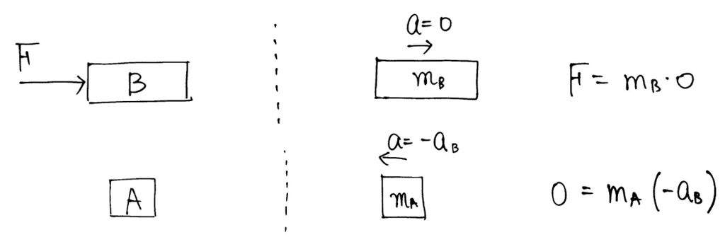

- Is Newton’s Law wrong ?
  - Observation (reference) frame is accelerating !!!
  - Frame moves with $a_B$

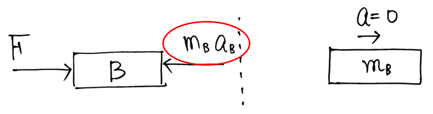

$$F - m_Ba_B = m_B \cdot 0$$

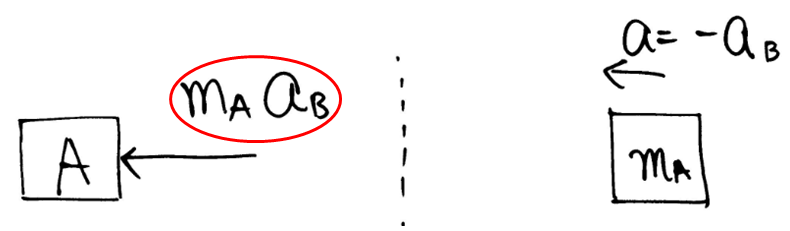

$$-m_Aa_B = m_A(-a_B)$$

```matlab
%%html
<iframe
width="560" height="315" src="https://www.youtube.com/embed/My2z65pkpuM" frameborder="0" allowfullscreen>
</iframe>
```

[video not shown]

```matlab
%%html
<iframe
width="560" height="315" src="https://www.youtube.com/embed/y8mzDvpKzfY" frameborder="0" allowfullscreen>
</iframe>
```

[video not shown]

```matlab
%%html
<iframe
width="560" height="315" src="https://www.youtube.com/embed/FjuMvUbT8gA" frameborder="0" allowfullscreen>
</iframe>
```

[video not shown]

**Summary**

```matlab
%%html
<iframe
width="560" height="315" src="https://www.youtube.com/embed/z0ijwmYLHhw?list=PLBD_gON7g_m17lIledteTg4CeySTCbEsc"
frameborder="0" allowfullscreen>
</iframe>
```

[video not shown]

```matlab
%%html
<iframe
width="560" height="315" src="https://www.youtube.com/embed/HoCLWQApN1M?list=PLBD_gON7g_m17lIledteTg4CeySTCbEsc"
frameborder="0" allowfullscreen>
</iframe>
```

[video not shown]

**Problem 3 revisited**

Find $\vec a$ for $m$ and $M$

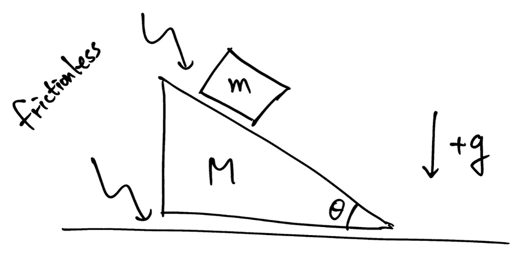

# 5. What is Weight?

## 5.1. Weight

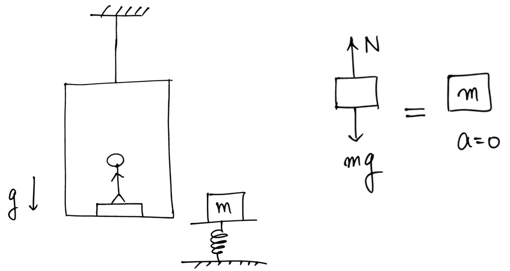

$$N - mg = m \cdot 0$$

$$\text{Spring is compressed by } x$$ $$N = + kx \\$$ $$\text{Weight = Normal force on a scale}$$

## 5.2. Inside elevator

### Example - Weight with an upward accelerating Elevator

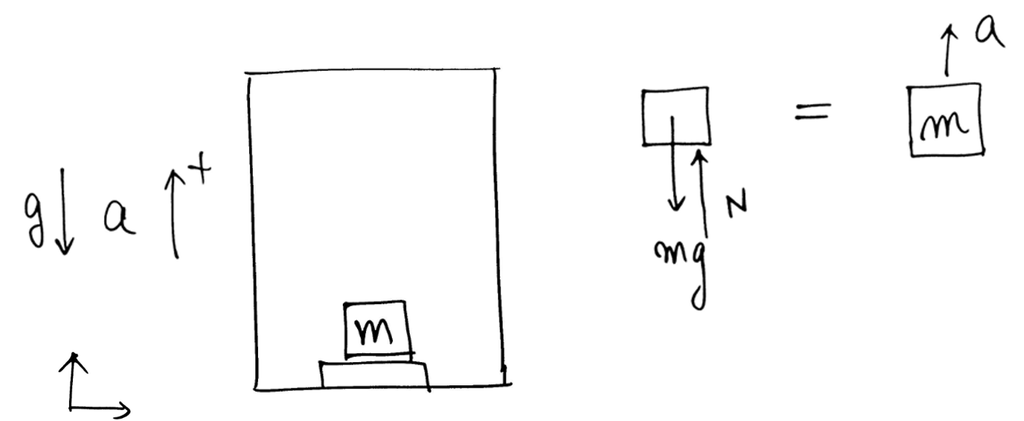

$$\begin{align*} N - mg &= ma\\ N &= m(g+a)\\ \\ \implies &\text{gain weight} \end{align*}$$

### Example – Weight observed inside an upward Accelerating Elevator

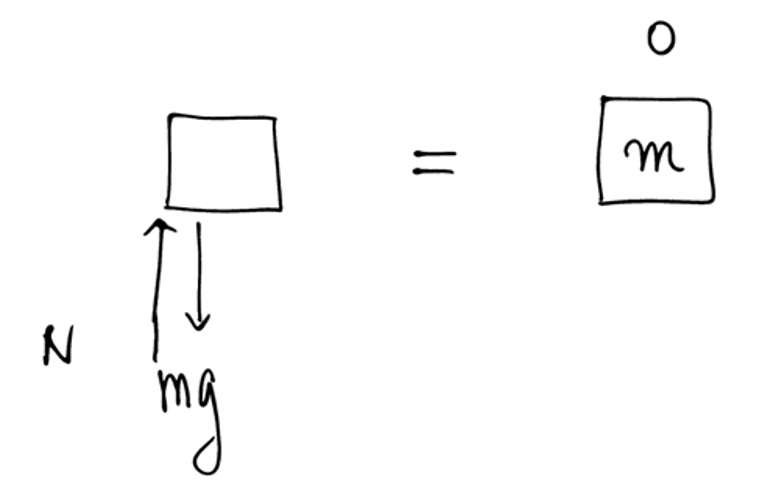

$$N - mg - ma = 0$$

```matlab
%%html
<iframe
width="420" height="315" src="https://www.youtube.com/embed/D-GzuZjawNI" frameborder="0" allowfullscreen>
</iframe>
```

[video not shown]

```matlab
%%html
<iframe
width="420" height="315" src="https://www.youtube.com/embed/etcZNxQPPaY" frameborder="0" allowfullscreen>
</iframe>
```

[video not shown]

## 5.3. What is weight in tension?

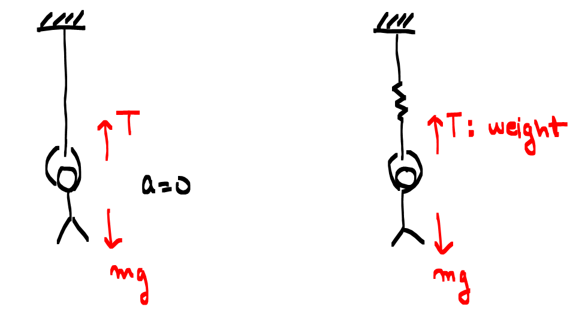

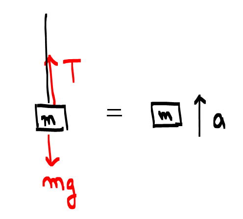

$$T - mg = ma$$

## 5.4. Force in a circular motion

**Example – Inertial circular frame**

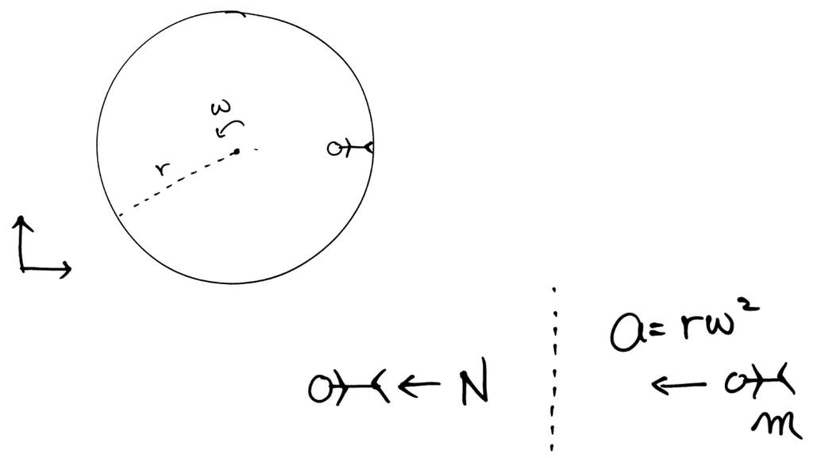

$$N = mr\omega^2$$

**Example – Non inertial circular frame**

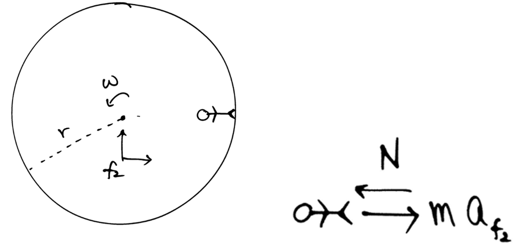

$$a = 0$$$$ - N + mr\omega^2 = m\cdot0$$$$a_{f_2} \text{ : feels like a gravitatial acceleration}$$

**Problem**

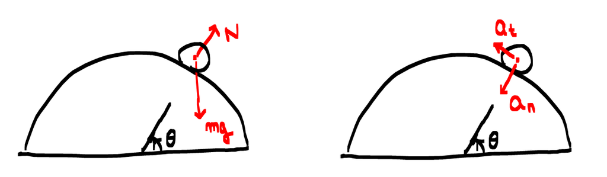

**Problem**

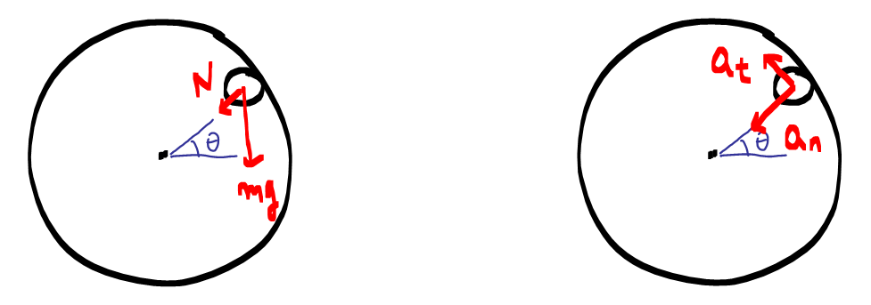

# 6. Problems with Pulleys

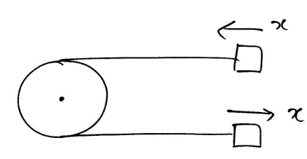

Ignore (mass, moment of inertia) of a pulley $\implies$ It only changes directions

## 6.1. Tension on a string is uniform (?)

Think of a small piece of string segment

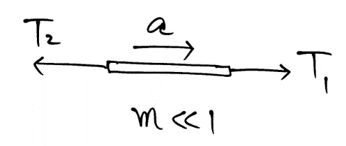

$$ \begin{align*} \text{if } T_1 &\neq T_2\\ T_1 - T_2 &= ma \end{align*} \quad \text{: might have almost infinite acceleration} $$

## 6.2. Example - pulley

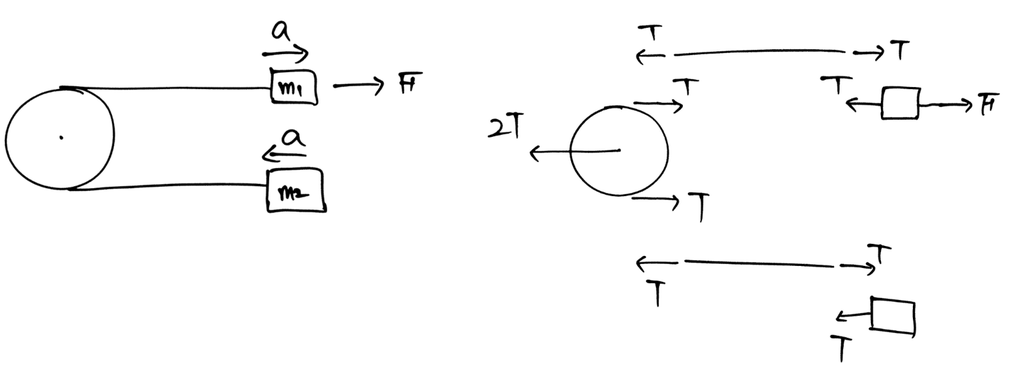

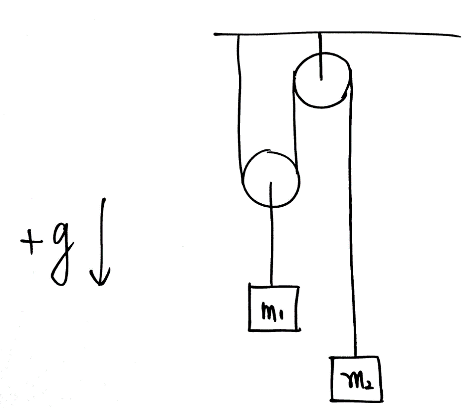

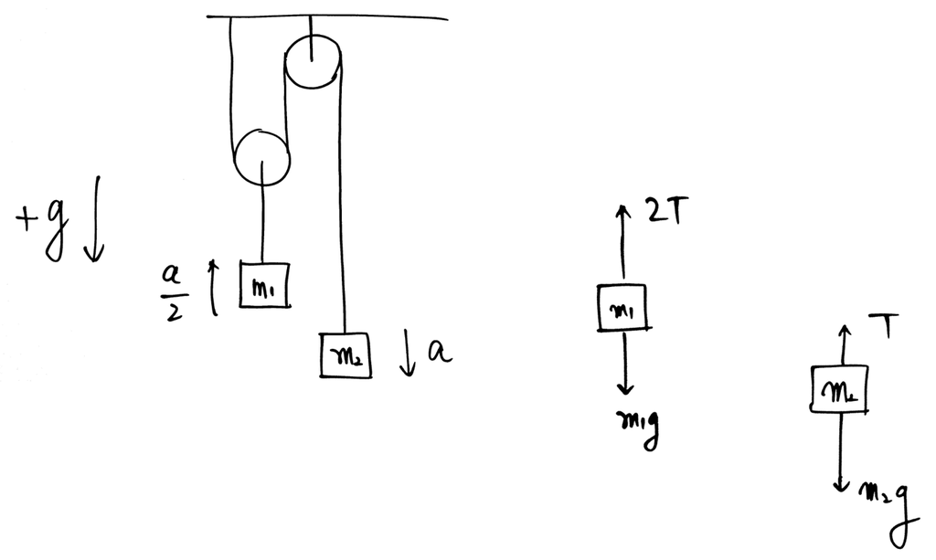

# 7. Question on Newton's Law

```matlab
%%html
<iframe
width="420" height="315" src="https://www.youtube.com/embed/_TeW04Le-rg" frameborder="0" allowfullscreen>
</iframe>
```

[video not shown]

# 8. Angular Dynamics on Circular Motion

We begin our discussion of rotational dynamics and rotational motion. We will start by introducing the concept of torque, the new manifestation of forces that produce a change in rotational motion.

- Interactions $\rightarrow$ Force $\rightarrow$ Change in **translational** motion

To include rotational motion, the net torque applied to a rigid body will produce a change in rotational motion:

- Interactions $\rightarrow$ Force $\rightarrow$ Torque $\rightarrow$ Change in **rotational** motion

## 8.1. Kinematics on circular motion

$$ \begin{align*}\displaystyle \omega(t) &= \frac{d\theta(t)}{dt} &\text{units:}\, [\omega]=\text{rad/s}\\ \displaystyle \alpha(t) &= \frac{d\omega(t)}{dt} = \frac{d^{2}\theta(t)}{dt^2} &\text{units:}\, [\alpha] = \text{rad/s}^2\end{align*}$$

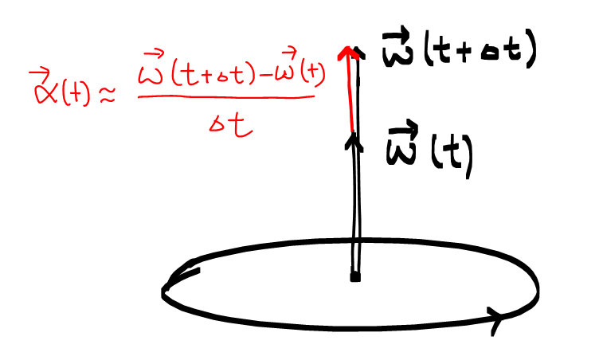

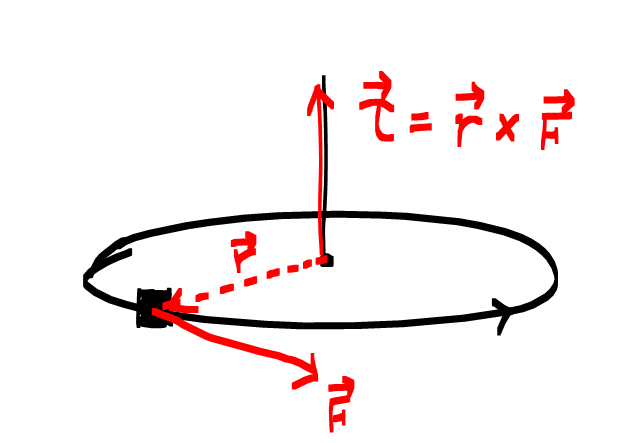

## 8.2. Torque about an Axis

In our study of translational motion under force, the location where the force was applied to the system did not matter. The subsequent translational motion only depended on the magnitude and direction of the net force. We will see that this simplification no longer holds for rotational motion. Forces applied to a body in an attempt to produce rotation will have different effects depending on the location of application and the direction of the applied force.

Consider trying to close a door by applying a force to the door near the hinges or in the middle of the door. Getting the door to close is much easier when the force is applied far from the hinges (see force $F_3$ in the figure below). This is why we usually place door handles by the edge opposite the hinges.

A well chosen location is not enough to guarantee effective rotation from an applied force. Consider another experiment. Suppose that you stand at the edge of an open door and push the door edge toward the hinges (see the force $F_1$ in the figure below). The door will not rotate, even with a hard push. This indicates that the direction of the force also affects the rotation produced.

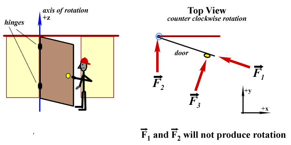

**Definition of Torque**

Consider a force $\vec{F}$ that is applied at a given point **A** as shown in the figure below. We say that this force produces a torque about point Q. The torque produced is a vector $\vec{\tau}$ is defined by the vector product :

$$\begin{align} \vec{\tau} = \vec{r}\times \vec{F} \end{align}$$

where the vector $\vec{r}$ is the position vector of the point **A** measured from point **Q**. (see below).

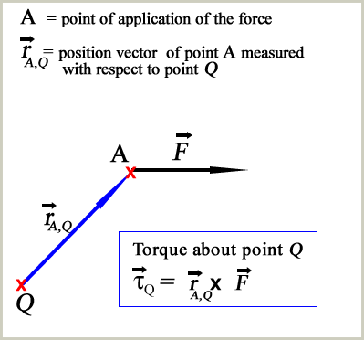

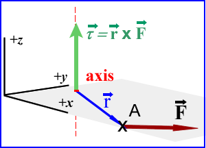

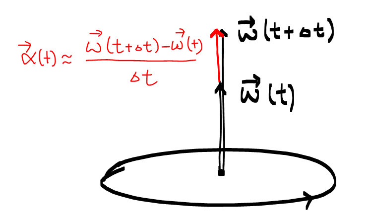

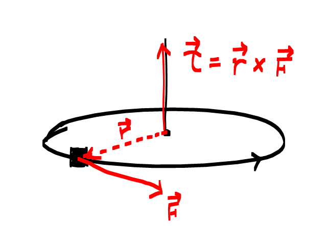

| $$\begin{align*} \tau_{net} &\,\text{ causes }\,\alpha\\ \tau_{net} &= I \cdot \alpha \end{align*} $$ | $$\begin{align*} \text{like } \, F_{net} &\,\text{ causes }\,a\\ \text{like } \, F_{net} &= m \cdot a \end{align*} $$ |
| --- | --- |

$$ \begin{align*} \tau &= rF = I \alpha = mr^2 \alpha\\ &\implies F = m \cdot r \alpha \\ &\implies F = m a \end{align*} $$

## 8.3. Torque = Moment

- How can we generate the moment?
- Vector
  - Magnitude
  - Direction (not obvious)

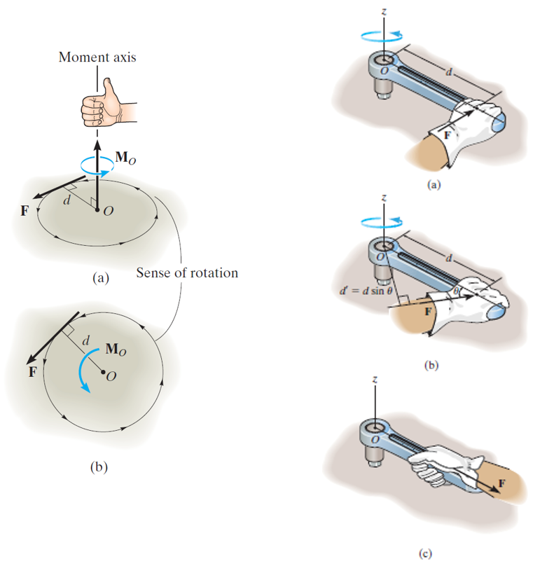

```matlab
%%html
<iframe
width="560" height="315" src="https://www.youtube.com/embed/qDjZf7O20Cg" frameborder="0" allowfullscreen>
</iframe>
```

[video not shown]

## 8.3. Moment of Inertia

moment of inertia = roational mass
$$I = \sum_{i} m_i r_i^2$$

Just as mass quantifies the resistance of an object to changes in linear velocity, the moment of inertia, also called rotational inertia, quantifies the resistance of an object to changes in angular velocity. A system's moment of inertia depends on

- about what axis the system rotates,
- the mass of the system,
- how the mass is distributed—is it far from the rotation axis, or near the rotation axis?

moment of inertia for other rigid bodies

[figure not shown]

```matlab
%%html
<iframe
width="560" height="315" src="https://www.youtube.com/embed/zesZg4FutAE" frameborder="0" allowfullscreen>
</iframe>
```

[video not shown]

**Analogy of Rotational Dynamics with Translation Dynamics (Newton's Second Law)**

By analogy to the manner in which force changes velocity

$$\sum\vec{F}=m \frac{d \vec{v}}{dt} =m\vec{a}$$

the angular dynamics and net torque model has a similar equation of change, but for rotational velocity around a fixed axis. If we apply a non zero torque on an object (e.g. push or pull on a door handle), it will result in a change of rotational motion - e.g. the door will start to rotate faster or slower about its (fixed) hinges.

By analogy, the angular velocity of an object rotating about an axis that passes through a point $Q$, is changed by the net torque on the object measured about point Q:

$$\sum\vec{\tau}_{\small{Q}} = I_Q \frac{d \vec \omega}{dt} = I_Q \vec{\alpha}$$

Where $\alpha$ is the angular acceleration: the rate of change of the angular speed $\omega$, and $\displaystyle I_Q$ is the moment of inertia about point $Q$, a quantity that is analogous to the inertial mass in $\sum\vec{F}=m\vec{a}$.

```matlab
%%javascript
$.getScript('https://kmahelona.github.io/ipython_notebook_goodies/ipython_notebook_toc.js')
```